# Proyecto_RNAseq

Análisis de Expresión Diferencial

Karla Ximena González Platas

2025-02-05

## Introducción

El conjunto de datos analizado en este proyecto se deriva del estudio de Muluhngwi y Klinge (2021), que explora las interacciones regulatorias entre los miembros de la familia miR-29 y los lncRNAs (ARN largos no codificantes) en el contexto de la resistencia a la terapia endocrina. En este estudio, se aplicó el análisis de RNA-seq para investigar la expresión de lncRNAs regulados por miR-29b-1-3p y miR-29a-3p en células de cáncer de mama sensibles a la terapia endocrina (MCF-7) y resistentes a la terapia endocrina (LCC9). Estas líneas celulares fueron empleadas para estudiar los efectos de la regulación de lncRNAs por los miR-29b-1-3p y miR-29a-3p en la resistencia endocrina del cáncer de mama. Para ello, se realizaron transfecciones en las células MCF-7 y LCC9 con pre-miR-29b-1-3p y pre-miR-29a-3p para evaluar los efectos de su sobreexpresión en la proliferación celular y en la regulación de lncRNAs. Mientras tanto, el uso de anti-miR-29 y un control negativo permitió analizar la inhibición de estos miRNAs.(Muluhngwi and Klinge 2021)

## Pregunta de investigación

¿Cuáles son los genes diferencialmente expresados entre las células de cáncer de mama sensibles (MCF-7) y resistentes (LCC9) a la terapia endocrina, y cómo se ven afectados por la sobreexpresión e inhibición de miR-29a y miR-29b-1?

## Hipótesis

La sobreexpresión de miR-29a y miR-29b-1 en las células de cáncer de mama sensibles (MCF-7) y resistentes (LCC9) a la terapia endocrina altera la expresión de genes involucrados en la resistencia a los tratamientos.

## Instalación y carga de paquetes

```r
# Instalar BiocManager si no está instalado
#if (!requireNamespace("BiocManager", quietly = TRUE)) {
#    install.packages("BiocManager")
#}

# Instalar paquetes de Bioconductor
#BiocManager::install(
#    c(
#        "edgeR",
#        "ExploreModelMatrix",
#        "limma",
#        "recount3",
#        "SummarizedExperiment",
#        "GenomicRanges"
#    )
#)

# Instalar paquetes de CRAN
#install.packages(c(
#    "pheatmap",
#    "patchwork",
#    "RColorBrewer",
#    "cowplot"
#))

## Cargar los paquetes
library("recount3")
library("SummarizedExperiment")
library("GenomicRanges")
library("limma")
library("edgeR")
library("ExploreModelMatrix")
library("cowplot")
library("RColorBrewer")
library("pheatmap")
```

## Selección de Proyecto

```r
# Obtener la lista de proyectos disponibles
human_projects <- available_projects()
```

```
## 2025-02-08 11:46:39.040686 caching file sra.recount_project.MD.gz.
```

```
## 2025-02-08 11:46:40.073684 caching file gtex.recount_project.MD.gz.
```

```
## 2025-02-08 11:46:40.718502 caching file tcga.recount_project.MD.gz.
```

```r
# Ver los proyectos disponibles
dim(human_projects)
```

```
## [1] 8742    6
```

```r
# Esto nos indica cuántos proyectos están disponibles (número de filas)
# y cuántas columnas de información se proporcionan para cada proyecto.

# Mostrar las primeras filas para inspeccionar su estructura y contenido
head(human_projects)
```

|  | project | organism | file_source | project_home | project_type | n_samples |
| --- | --- | --- | --- | --- | --- | --- |
| 1 | SRP107565 | human | sra | data_sources/sra | data_sources | 216 |
| 2 | SRP149665 | human | sra | data_sources/sra | data_sources | 4 |
| 3 | SRP017465 | human | sra | data_sources/sra | data_sources | 23 |
| 4 | SRP119165 | human | sra | data_sources/sra | data_sources | 6 |
| 5 | SRP133965 | human | sra | data_sources/sra | data_sources | 12 |
| 6 | SRP096765 | human | sra | data_sources/sra | data_sources | 7 |

```r
# Seleccionar un estudio de interés
human_projects[709, ]
```

|  | project | organism | file_source | project_home | project_type | n_samples |
| --- | --- | --- | --- | --- | --- | --- |
| 709 | SRP075398 | human | sra | data_sources/sra | data_sources | 18 |

```r
# Filtrar el dataframe para seleccionar un proyecto específico basado en su ID y tipo
project_info <- subset(
  human_projects,
  project == "SRP075398" & project_type == "data_sources"
)

# Mostrar la información del proyecto seleccionado para confirmar que se ha
# filtrado correctamente
project_info
```

|  | project | organism | file_source | project_home | project_type | n_samples |
| --- | --- | --- | --- | --- | --- | --- |
| 709 | SRP075398 | human | sra | data_sources/sra | data_sources | 18 |

```r
# Crear un objeto de tipo RangedSummarizedExperiment (RSE) con la información
# a nivel de genes
rse_gene_SRP075398 <- create_rse(project_info)
```

```
## 2025-02-08 11:46:49.334794 downloading and reading the metadata.
```

```
## 2025-02-08 11:46:50.158992 caching file sra.sra.SRP075398.MD.gz.
```

```
## 2025-02-08 11:46:50.767726 caching file sra.recount_project.SRP075398.MD.gz.
```

```
## 2025-02-08 11:46:51.371716 caching file sra.recount_qc.SRP075398.MD.gz.
```

```
## 2025-02-08 11:46:51.989476 caching file sra.recount_seq_qc.SRP075398.MD.gz.
```

```
## 2025-02-08 11:46:52.606256 caching file sra.recount_pred.SRP075398.MD.gz.
```

```
## 2025-02-08 11:46:52.864151 downloading and reading the feature information.
```

```
## 2025-02-08 11:46:53.311688 caching file human.gene_sums.G026.gtf.gz.
```

```
## 2025-02-08 11:46:54.526823 downloading and reading the counts: 18 samples across 63856 features.
```

```
## 2025-02-08 11:46:54.993431 caching file sra.gene_sums.SRP075398.G026.gz.
```

```
## 2025-02-08 11:46:55.685179 constructing the RangedSummarizedExperiment (rse) object.
```

```r
# Explorar el objeto RSE
rse_gene_SRP075398
```

```
## class: RangedSummarizedExperiment
## dim: 63856 18
## metadata(8): time_created recount3_version ... annotation recount3_url
## assays(1): raw_counts
## rownames(63856): ENSG00000278704.1 ENSG00000277400.1 ...
##   ENSG00000182484.15_PAR_Y ENSG00000227159.8_PAR_Y
## rowData names(10): source type ... havana_gene tag
## colnames(18): SRR3544525 SRR3544526 ... SRR3544537 SRR3544540
## colData names(175): rail_id external_id ...
##   recount_pred.curated.cell_line BigWigURL
```

```r
## Información sobre el RSE creado
metadata(rse_gene_SRP075398)
```

```
## $time_created
## [1] "2025-02-08 11:46:55 CST"
##
## $recount3_version
##           package ondiskversion loadedversion
## recount3 recount3        1.16.0        1.16.0
##                                            path
## recount3 /usr/local/lib/R/site-library/recount3
##                                      loadedpath attached is_base       date
## recount3 /usr/local/lib/R/site-library/recount3     TRUE   FALSE 2024-10-29
##                               source md5ok                       library
## recount3 Bioconductor 3.20 (R 4.4.2)    NA /usr/local/lib/R/site-library
##
## $project
## [1] "SRP075398"
##
## $project_home
## [1] "data_sources/sra"
##
## $type
## [1] "gene"
##
## $organism
## [1] "human"
##
## $annotation
## [1] "gencode_v26"
##
## $recount3_url
## [1] "http://duffel.rail.bio/recount3"
```

```r
## Número de genes y número de muestras
dim(rse_gene_SRP075398)
```

```
## [1] 63856    18
```

El estudio **SRP075398** se compuso de **18 muestras**, para las cuales tenemos **63,856 genes** en GENCODE v26. La información específica de la anotación está disponible rowRanges() como se muestra a continuación con la columna gene_id utilizada para identificar genes en cada una de las anotaciones.

```r
# Información sobre los genes
rowRanges(rse_gene_SRP075398)
```

```
## GRanges object with 63856 ranges and 10 metadata columns:
##                              seqnames            ranges strand |   source
##                                 <Rle>         <IRanges>  <Rle> | <factor>
##          ENSG00000278704.1 GL000009.2       56140-58376      - |  ENSEMBL
##          ENSG00000277400.1 GL000194.1      53590-115018      - |  ENSEMBL
##          ENSG00000274847.1 GL000194.1      53594-115055      - |  ENSEMBL
##          ENSG00000277428.1 GL000195.1       37434-37534      - |  ENSEMBL
##          ENSG00000276256.1 GL000195.1       42939-49164      - |  ENSEMBL
##                        ...        ...               ...    ... .      ...
##   ENSG00000124334.17_PAR_Y       chrY 57184101-57197337      + |   HAVANA
##   ENSG00000185203.12_PAR_Y       chrY 57201143-57203357      - |   HAVANA
##    ENSG00000270726.6_PAR_Y       chrY 57190738-57208756      + |   HAVANA
##   ENSG00000182484.15_PAR_Y       chrY 57207346-57212230      + |   HAVANA
##    ENSG00000227159.8_PAR_Y       chrY 57212184-57214397      - |   HAVANA
##                                type bp_length     phase                gene_id
##                            <factor> <numeric> <integer>            <character>
##          ENSG00000278704.1     gene      2237      <NA>      ENSG00000278704.1
##          ENSG00000277400.1     gene      2179      <NA>      ENSG00000277400.1
##          ENSG00000274847.1     gene      1599      <NA>      ENSG00000274847.1
##          ENSG00000277428.1     gene       101      <NA>      ENSG00000277428.1
##          ENSG00000276256.1     gene      2195      <NA>      ENSG00000276256.1
##                        ...      ...       ...       ...                    ...
##   ENSG00000124334.17_PAR_Y     gene      2504      <NA> ENSG00000124334.17_P..
##   ENSG00000185203.12_PAR_Y     gene      1054      <NA> ENSG00000185203.12_P..
##    ENSG00000270726.6_PAR_Y     gene       773      <NA> ENSG00000270726.6_PA..
##   ENSG00000182484.15_PAR_Y     gene      4618      <NA> ENSG00000182484.15_P..
##    ENSG00000227159.8_PAR_Y     gene      1306      <NA> ENSG00000227159.8_PA..
##                                         gene_type   gene_name       level
##                                       <character> <character> <character>
##          ENSG00000278704.1         protein_coding  BX004987.1           3
##          ENSG00000277400.1         protein_coding  AC145212.2           3
##          ENSG00000274847.1         protein_coding  AC145212.1           3
##          ENSG00000277428.1               misc_RNA       Y_RNA           3
##          ENSG00000276256.1         protein_coding  AC011043.1           3
##                        ...                    ...         ...         ...
##   ENSG00000124334.17_PAR_Y         protein_coding        IL9R           2
##   ENSG00000185203.12_PAR_Y              antisense      WASIR1           2
##    ENSG00000270726.6_PAR_Y   processed_transcript AJ271736.10           2
##   ENSG00000182484.15_PAR_Y transcribed_unproces..      WASH6P           2
##    ENSG00000227159.8_PAR_Y unprocessed_pseudogene    DDX11L16           2
##                                     havana_gene         tag
##                                     <character> <character>
##          ENSG00000278704.1                 <NA>        <NA>
##          ENSG00000277400.1                 <NA>        <NA>
##          ENSG00000274847.1                 <NA>        <NA>
##          ENSG00000277428.1                 <NA>        <NA>
##          ENSG00000276256.1                 <NA>        <NA>
##                        ...                  ...         ...
##   ENSG00000124334.17_PAR_Y OTTHUMG00000022720.1         PAR
##   ENSG00000185203.12_PAR_Y OTTHUMG00000022676.3         PAR
##    ENSG00000270726.6_PAR_Y OTTHUMG00000184987.2         PAR
##   ENSG00000182484.15_PAR_Y OTTHUMG00000022677.5         PAR
##    ENSG00000227159.8_PAR_Y OTTHUMG00000022678.1         PAR
##   -------
##   seqinfo: 374 sequences from an unspecified genome; no seqlengths
```

## Preparación de los datos

```r
# Convertir las cuentas por nucleotido a cuentas por lectura usando compute_read_counts()
assay(rse_gene_SRP075398, "counts") <- compute_read_counts(rse_gene_SRP075398)

# Inspeccionar la información experimental de cada muestra
rse_gene_SRP075398$sra.sample_attributes[]
```

```
##  [1] "cell line;;LCC9|source_name;;LCC9 cell line pre-miR-29b-1 transfected|transfection;;Pre-miR-29b-1"
##  [2] "cell line;;LCC9|source_name;;LCC9 cell line Anti-miR-29a transfected|transfection;;Anti-miR-29a"
##  [3] "cell line;;LCC9|source_name;;LCC9 cell line Anti-miR-29a transfected|transfection;;Anti-miR-29a"
##  [4] "cell line;;LCC9|source_name;;LCC9 cell line Anti-miR-29a transfected|transfection;;Anti-miR-29a"
##  [5] "cell line;;LCC9|source_name;;LCC9 cell line Pre-miR-29a transfected|transfection;;Pre-miR-29a"
##  [6] "cell line;;LCC9|source_name;;LCC9 cell line Pre-miR-29a transfected|transfection;;Pre-miR-29a"
##  [7] "cell line;;LCC9|source_name;;LCC9 cell line Pre-miR-29a transfected|transfection;;Pre-miR-29a"
##  [8] "cell line;;MCF-7|source_name;;MCF-7 cell line pre-miR-29b-1 transfected|transfection;;Pre-miR-29b-1"
##  [9] "cell line;;MCF-7|source_name;;MCF-7 cell line pre-miR-29b-1 transfected|transfection;;Pre-miR-29b-1"
## [10] "cell line;;MCF-7|source_name;;MCF-7 cell line Pre-miR-29a transfected|transfection;;Pre-miR-29a"
## [11] "cell line;;MCF-7|source_name;;MCF-7 cell line Pre-miR-29a transfected|transfection;;Pre-miR-29a"
## [12] "cell line;;LCC9|source_name;;LCC9 cell line pre-miR-29b-1 transfected|transfection;;Pre-miR-29b-1"
## [13] "cell line;;LCC9|source_name;;LCC9 cell line pre-miR-29b-1 transfected|transfection;;Pre-miR-29b-1"
## [14] "cell line;;MCF-7|source_name;;MCF-7 cell line pre-miR-29b-1 transfected|transfection;;Pre-miR-29b-1"
## [15] "cell line;;MCF-7|source_name;;MCF-7 cell line Anti-miR-29a transfected|transfection;;Anti-miR-29a"
## [16] "cell line;;MCF-7|source_name;;MCF-7 cell line Anti-miR-29a transfected|transfection;;Anti-miR-29a"
## [17] "cell line;;MCF-7|source_name;;MCF-7 cell line Anti-miR-29a transfected|transfection;;Anti-miR-29a"
## [18] "cell line;;MCF-7|source_name;;MCF-7 cell line Pre-miR-29a transfected|transfection;;Pre-miR-29a"
```

```r
# Expandir los atributos en columnas separadas para facilitar su uso
rse_gene_SRP075398 <- expand_sra_attributes(rse_gene_SRP075398)

# Extraer y mostrar las columnas que contienen atributos
colData(rse_gene_SRP075398)[
  ,
  grepl("^sra_attribute", colnames(colData(rse_gene_SRP075398)))
]
```

```
## DataFrame with 18 rows and 3 columns
##            sra_attribute.cell_line sra_attribute.source_name
##                        <character>               <character>
## SRR3544525                    LCC9    LCC9 cell line pre-m..
## SRR3544526                    LCC9    LCC9 cell line Anti-..
## SRR3544527                    LCC9    LCC9 cell line Anti-..
## SRR3544528                    LCC9    LCC9 cell line Anti-..
## SRR3544529                    LCC9    LCC9 cell line Pre-m..
## ...                            ...                       ...
## SRR3544534                   MCF-7    MCF-7 cell line pre-..
## SRR3544535                   MCF-7    MCF-7 cell line Anti..
## SRR3544536                   MCF-7    MCF-7 cell line Anti..
## SRR3544537                   MCF-7    MCF-7 cell line Anti..
## SRR3544540                   MCF-7    MCF-7 cell line Pre-..
##            sra_attribute.transfection
##                           <character>
## SRR3544525              Pre-miR-29b-1
## SRR3544526               Anti-miR-29a
## SRR3544527               Anti-miR-29a
## SRR3544528               Anti-miR-29a
## SRR3544529                Pre-miR-29a
## ...                               ...
## SRR3544534              Pre-miR-29b-1
## SRR3544535               Anti-miR-29a
## SRR3544536               Anti-miR-29a
## SRR3544537               Anti-miR-29a
## SRR3544540                Pre-miR-29a
```

```r
# Ajustar el tipo de dato de las variables categóricas

rse_gene_SRP075398$sra_attribute.cell_line <-
  factor(rse_gene_SRP075398$sra_attribute.cell_line)

rse_gene_SRP075398$sra_attribute.source_name <-
  factor(tolower(rse_gene_SRP075398$sra_attribute.source_name))

rse_gene_SRP075398$sra_attribute.transfection <-
  factor(rse_gene_SRP075398$sra_attribute.transfection)

# Resumen estadístico de las variables seleccionadas
summary(as.data.frame(colData(rse_gene_SRP075398)[
    ,
    grepl("^sra_attribute.[cell_line|source_name|transfection]",
          colnames(colData(rse_gene_SRP075398)))
    ]))
```

```
##  sra_attribute.cell_line                             sra_attribute.source_name
##  LCC9 :9                 lcc9 cell line anti-mir-29a transfected  :3
##  MCF-7:9                 lcc9 cell line pre-mir-29a transfected   :3
##                          lcc9 cell line pre-mir-29b-1 transfected :3
##                          mcf-7 cell line anti-mir-29a transfected :3
##                          mcf-7 cell line pre-mir-29a transfected  :3
##                          mcf-7 cell line pre-mir-29b-1 transfected:3
##  sra_attribute.transfection
##  Anti-miR-29a :6
##  Pre-miR-29a  :6
##  Pre-miR-29b-1:6
##
##
##
```

```r
# Calcular la proporción de lecturas asignadas a genes para evaluar la calidad
# de las muestras

rse_gene_SRP075398$assigned_gene_prop <-
  rse_gene_SRP075398$recount_qc.gene_fc_count_all.assigned /
  rse_gene_SRP075398$recount_qc.gene_fc_count_all.total

# Resumen de la nueva variable para identificar si las muestras tienen una
# asignación adecuada de lecturas (valores cercanos a 1 son indicadores de buena calidad)

summary(rse_gene_SRP075398$assigned_gene_prop)
```

```
##    Min. 1st Qu.  Median    Mean 3rd Qu.    Max.
##  0.6076  0.6405  0.6603  0.6585  0.6696  0.7017
```

## Filtrar genes de baja expresión

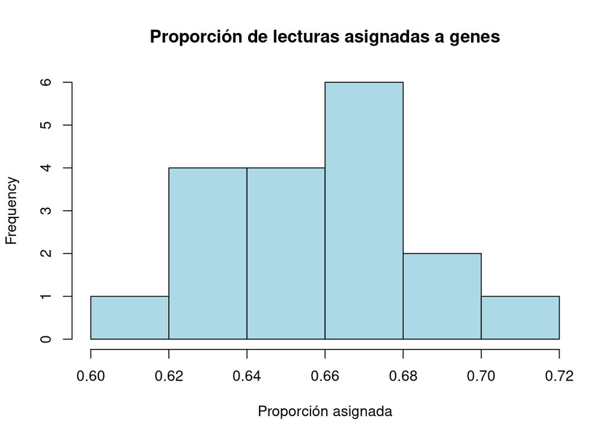

Histograma

```r
# Guardar el objeto original
rse_gene_SRP075398_unfiltered <- rse_gene_SRP075398

# Visualizar la distribución de la proporción de lecturas asignadas a genes en
# cada muestra

hist(rse_gene_SRP075398$assigned_gene_prop,
     main = "Proporción de lecturas asignadas a genes",
     xlab = "Proporción asignada", col = "lightblue")
```

```r
# Verificar si existen muestras de baja calidad antes del filtrado
table(rse_gene_SRP075398$assigned_gene_prop < 0.3)
```

```
##
## FALSE
##    18
```

```r
# Filtrar las muestras con proporción de lecturas asignadas superior a 0.3
rse_gene_SRP075398 <- rse_gene_SRP075398[, rse_gene_SRP075398$assigned_gene_prop > 0.3]

# Crear un objeto DGEList, para el análisis diferencial usando edgeR
dge <- DGEList(counts = assay(rse_gene_SRP075398, "counts"))

# Filtrar genes de baja expresión considerando combinaciones de transfección y
# línea celular
keep <- filterByExpr(dge, group = interaction(
  rse_gene_SRP075398$sra_attribute.transfection,
  rse_gene_SRP075398$sra_attribute.cell_line
))
rse_gene_SRP075398 <- rse_gene_SRP075398[keep, ]

# Dimensiones finales
dim(rse_gene_SRP075398)
```

```
## [1] 23741    18
```

```r
# Porcentaje de genes retenidos
round(nrow(rse_gene_SRP075398) / nrow(rse_gene_SRP075398_unfiltered) * 100, 2)
```

```
## [1] 37.18
```

Se descartó los genes de baja expresión porque no contribuyen significativamente a las conclusiones biológicas. De modo que, después del filtrado se obtuvieron **23,741** lo cual representa el **37.18%** de genes retenidos.

## Normalización de los datos

```r
# Crear un objeto DGEList para normalización
dge <- DGEList(
    counts = assay(rse_gene_SRP075398, "counts"),
    genes = rowData(rse_gene_SRP075398)
)

# Normalización TMM
dge <- calcNormFactors(dge)

dge
```

```
## An object of class "DGEList"
## $counts
##                   SRR3544525 SRR3544526 SRR3544527 SRR3544528 SRR3544529
## ENSG00000223972.5         44         31         54         44         62
## ENSG00000227232.5        297        264        405        352        242
## ENSG00000238009.6         32         27         19         32         20
## ENSG00000233750.3         10         15          6          1          9
## ENSG00000268903.1         17          7          9          6         17
##                   SRR3544530 SRR3544531 SRR3544532 SRR3544533 SRR3544538
## ENSG00000223972.5         37         51         13         18         16
## ENSG00000227232.5        215        277        200        204        245
## ENSG00000238009.6         15         25         19         30         48
## ENSG00000233750.3          7          9         13          9         14
## ENSG00000268903.1          6         13          8          3          4
##                   SRR3544539 SRR3544523 SRR3544524 SRR3544534 SRR3544535
## ENSG00000223972.5         13         71         52         10         11
## ENSG00000227232.5        105        509        353        217        123
## ENSG00000238009.6         23         45         28         26         31
## ENSG00000233750.3          3         16          7          8          3
## ENSG00000268903.1          1         35         24          0          4
##                   SRR3544536 SRR3544537 SRR3544540
## ENSG00000223972.5          7          9         25
## ENSG00000227232.5         74        163        183
## ENSG00000238009.6         32         27         45
## ENSG00000233750.3          8          3          6
## ENSG00000268903.1          0          2          3
## 23736 more rows ...
##
## $samples
##            group lib.size norm.factors
## SRR3544525     1 40711468    1.0516143
## SRR3544526     1 44717701    1.0300052
## SRR3544527     1 55798559    0.9927744
## SRR3544528     1 61298574    0.9995922
## SRR3544529     1 34513836    1.0385196
## 13 more rows ...
##
## $genes
##                   source type bp_length phase           gene_id
## ENSG00000223972.5 HAVANA gene      1735    NA ENSG00000223972.5
## ENSG00000227232.5 HAVANA gene      1351    NA ENSG00000227232.5
## ENSG00000238009.6 HAVANA gene      3726    NA ENSG00000238009.6
## ENSG00000233750.3 HAVANA gene      3812    NA ENSG00000233750.3
## ENSG00000268903.1 HAVANA gene       755    NA ENSG00000268903.1
##                                            gene_type     gene_name level
## ENSG00000223972.5 transcribed_unprocessed_pseudogene       DDX11L1     2
## ENSG00000227232.5             unprocessed_pseudogene        WASH7P     2
## ENSG00000238009.6                            lincRNA  RP11-34P13.7     2
## ENSG00000233750.3               processed_pseudogene        CICP27     1
## ENSG00000268903.1               processed_pseudogene RP11-34P13.15     2
##                            havana_gene               tag
## ENSG00000223972.5 OTTHUMG00000000961.2              <NA>
## ENSG00000227232.5 OTTHUMG00000000958.1              <NA>
## ENSG00000238009.6 OTTHUMG00000001096.2 overlapping_locus
## ENSG00000233750.3 OTTHUMG00000001257.3    pseudo_consens
## ENSG00000268903.1 OTTHUMG00000182518.2              <NA>
## 23736 more rows ...
```

## Determinar el modelo estadístico

```r
# Construcción de la matriz de diseño para el modelo lineal.
mod <- model.matrix(
  ~ sra_attribute.cell_line + sra_attribute.transfection + assigned_gene_prop,
  data = colData(rse_gene_SRP075398)
)

# Cada columna representa un coeficiente del modelo
colnames(mod)
```

```
## [1] "(Intercept)"
## [2] "sra_attribute.cell_lineMCF-7"
## [3] "sra_attribute.transfectionPre-miR-29a"
## [4] "sra_attribute.transfectionPre-miR-29b-1"
## [5] "assigned_gene_prop"
```

```r
# Visualizar la matriz de diseño completa
# Las filas representan muestras, mientras que las columnas son las variables del modelo
mod
```

```
##            (Intercept) sra_attribute.cell_lineMCF-7
## SRR3544525           1                            0
## SRR3544526           1                            0
## SRR3544527           1                            0
## SRR3544528           1                            0
## SRR3544529           1                            0
## SRR3544530           1                            0
## SRR3544531           1                            0
## SRR3544532           1                            1
## SRR3544533           1                            1
## SRR3544538           1                            1
## SRR3544539           1                            1
## SRR3544523           1                            0
## SRR3544524           1                            0
## SRR3544534           1                            1
## SRR3544535           1                            1
## SRR3544536           1                            1
## SRR3544537           1                            1
## SRR3544540           1                            1
##            sra_attribute.transfectionPre-miR-29a
## SRR3544525                                     0
## SRR3544526                                     0
## SRR3544527                                     0
## SRR3544528                                     0
## SRR3544529                                     1
## SRR3544530                                     1
## SRR3544531                                     1
## SRR3544532                                     0
## SRR3544533                                     0
## SRR3544538                                     1
## SRR3544539                                     1
## SRR3544523                                     0
## SRR3544524                                     0
## SRR3544534                                     0
## SRR3544535                                     0
## SRR3544536                                     0
## SRR3544537                                     0
## SRR3544540                                     1
##            sra_attribute.transfectionPre-miR-29b-1 assigned_gene_prop
## SRR3544525                                       1          0.6075824
```

[output cut: 10 more lines]

```
## SRR3544523                                       1          0.6586547
## SRR3544524                                       1          0.6286454
## SRR3544534                                       1          0.6352978
## SRR3544535                                       0          0.6539348
## SRR3544536                                       0          0.6907278
## SRR3544537                                       0          0.6651556
## SRR3544540                                       0          0.6725733
## attr(,"assign")
## [1] 0 1 2 2 3
## attr(,"contrasts")
## attr(,"contrasts")$sra_attribute.cell_line
## [1] "contr.treatment"
##
## attr(,"contrasts")$sra_attribute.transfection
## [1] "contr.treatment"
```

Es importante mencionar que la línea celular o el tipo de transfección que acompañan a cada variable del modelo son a los que se les otorga el valor de 1, debido a un orden alfabético. Por lo tanto, si la primera columna es “sra_attribute.cell_lineMCF-7”, la línea celular correspondiente a MCF-7 tendrá valor de 1 y la línea celular LCC9 de 0.

## Visualizar matriz

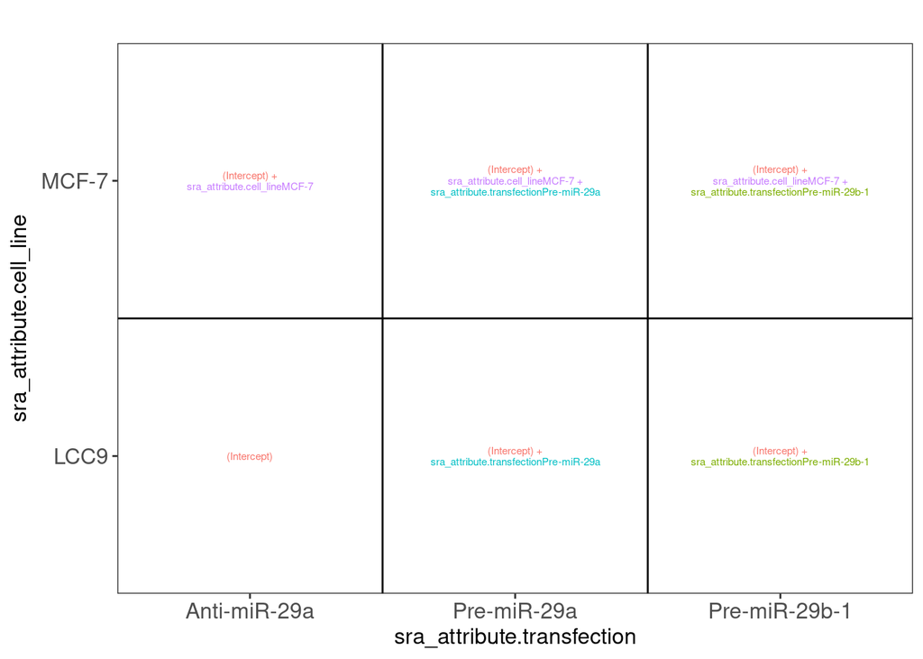

Matriz de coeficientes

```r
## Crear las visualizaciones
vd <- ExploreModelMatrix::VisualizeDesign(
    sampleData = colData(rse_gene_SRP075398), # Metadatos de las muestras
    designFormula = ~ sra_attribute.cell_line + sra_attribute.transfection,
    textSizeFitted = 2
)

cowplot::plot_grid(plotlist = vd$plotlist)
```

sra_attribute.cell_lineMCF-7: Este coeficiente es la diferencia entre la línea celular sensible al tratamiento (MCF-7), contra la línea celular resistente al tratamiento (LCC9), cuando la transfección se mantiene constante. De modo que, representa la diferencia en la respuesta entre la línea celular MCF-7 y la línea celular LCC9.

## Expresión diferencial

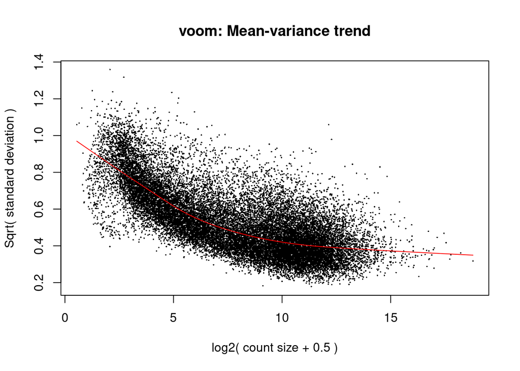

voom

```r
# Convertir los datos de conteo a valores log2 y ajusta las varianzas para
# hacerlos aptos para un análisis lineal

vGene <- voom(dge, mod, plot = TRUE)
```

El método voom estima la relación media-varianza de los recuentos logarítmicos, genera un peso de precisión para cada observación y los ingresa en el flujo de trabajo del análisis bayesiano empírico de Limma. Por lo tanto, este gráfico muestra la relación entre la media y la varianza de los datos de expresión génica en escala log2. En el eje X se observa la expresión promedio de los genes, mientras que el eje Y representa la raíz cuadrada de la desviación estándar. Los genes con baja expresión presentan mayor dispersión, mientras que a niveles altos de expresión la varianza disminuye y se estabiliza. (Law et al. 2014)

```r
# Ajuste del modelo lineal y cálculo de estadísticas empíricas de Bayes
eb_results <- eBayes(lmFit(vGene))


# Extraer la tabla de genes diferencialmente expresados.
de_results <- topTable(
    eb_results,
    coef = 2, # Se refiere al coeficiente del segundo término en el modelo
    number = nrow(rse_gene_SRP075398),
    sort.by = "none"
)

# Dimensiones y vista preliminar de los resultados
dim(de_results)
```

```
## [1] 23741    16
```

```r
head(de_results)
```

|  | source | type | bp_length | phase | gene_id | gene_type | gene_name | level | havana_gene | tag | logFC | AveExpr | t | P.Value | adj.P.Val | B |
| --- | --- | --- | --- | --- | --- | --- | --- | --- | --- | --- | --- | --- | --- | --- | --- | --- |
| ENSG00000223972.5 | HAVANA | gene | 1735 | NA | ENSG00000223972.5 | transcribed_unprocessed_pseudogene | DDX11L1 | 2 | OTTHUMG00000000961.2 | NA | -1.57964773 | -0.7349755 | -9.0583130 | 5.502604e-08 | 1.724585e-07 | 8.293369 |
| ENSG00000227232.5 | HAVANA | gene | 1351 | NA | ENSG00000227232.5 | unprocessed_pseudogene | WASH7P | 2 | OTTHUMG00000000958.1 | NA | -0.65730720 | 2.4021094 | -4.2492998 | 5.203366e-04 | 8.224575e-04 | -1.699547 |
| ENSG00000238009.6 | HAVANA | gene | 3726 | NA | ENSG00000238009.6 | lincRNA | RP11-34P13.7 | 2 | OTTHUMG00000001096.2 | overlapping_locus | 0.50892797 | -0.5758187 | 3.2989311 | 4.153389e-03 | 5.833271e-03 | -3.230385 |
| ENSG00000233750.3 | HAVANA | gene | 3812 | NA | ENSG00000233750.3 | processed_pseudogene | CICP27 | 1 | OTTHUMG00000001257.3 | pseudo_consens | 0.07505824 | -2.5024602 | 0.2097501 | 8.363087e-01 | 8.516989e-01 | -7.250773 |
| ENSG00000268903.1 | HAVANA | gene | 755 | NA | ENSG00000268903.1 | processed_pseudogene | RP11-34P13.15 | 2 | OTTHUMG00000182518.2 | NA | -2.26677866 | -2.9392186 | -4.8120051 | 1.545050e-04 | 2.624197e-04 | 0.559485 |
| ENSG00000269981.1 | HAVANA | gene | 284 | NA | ENSG00000269981.1 | processed_pseudogene | RP11-34P13.16 | 2 | OTTHUMG00000182738.2 | NA | -0.20655991 | -1.1726322 | -0.8707765 | 3.957782e-01 | 4.289509e-01 | -7.156075 |

El coeficiente 2 (sra_attribute.cell_lineMCF-7) evalúa la expresión diferencial entre las líneas celulares MCF-7 y LCC9, lo que podría permitir identificar genes relacionados con la resistencia a la terapia endocrina.

```r
# Genes diferencialmente expresados con FDR < 5%
table(de_results$adj.P.Val < 0.05)
```

```
##
## FALSE  TRUE
##  4642 19099
```

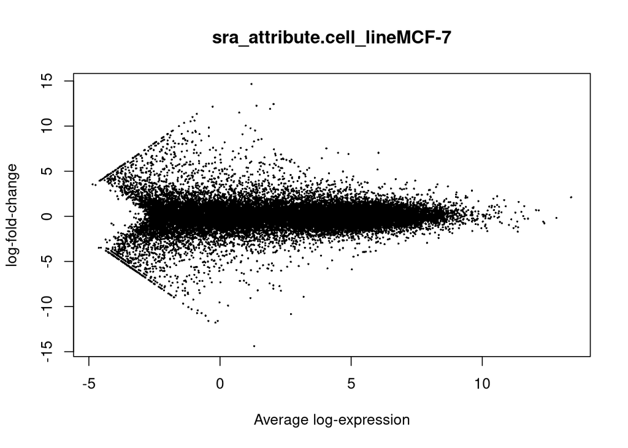

plotMA

```r
# Visualizar los resultados estadísticos

plotMA(eb_results, coef = 2)
```

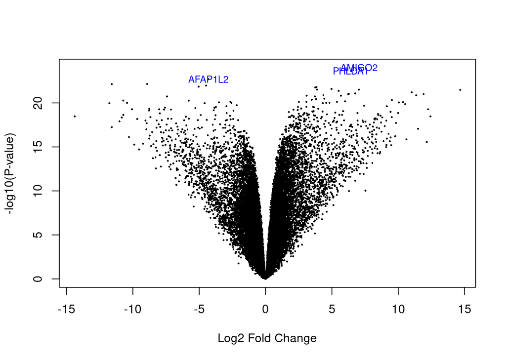

volcanoplot

```r
volcanoplot(eb_results, coef = 2, highlight = 3, names = de_results$gene_name)
```

```r
# Información de los 3 genes más significativos
de_results[de_results$gene_name %in% c("AMIGO2", "AFAP1L2", "PHLDA1"), ]
```

|  | source | type | bp_length | phase | gene_id | gene_type | gene_name | level | havana_gene | tag | logFC | AveExpr | t | P.Value | adj.P.Val | B |
| --- | --- | --- | --- | --- | --- | --- | --- | --- | --- | --- | --- | --- | --- | --- | --- | --- |
| ENSG00000169129.14 | HAVANA | gene | 5789 | NA | ENSG00000169129.14 | protein_coding | AFAP1L2 | 2 | OTTHUMG00000019086.3 | NA | -4.302232 | 5.257918 | -77.07393 | 1.991303e-23 | 1.575851e-19 | 43.77924 |
| ENSG00000139211.6 | HAVANA | gene | 3956 | NA | ENSG00000139211.6 | protein_coding | AMIGO2 | 2 | OTTHUMG00000169616.1 | NA | 7.038259 | 6.044177 | 91.73069 | 9.814316e-25 | 2.330017e-20 | 46.45332 |
| ENSG00000139289.13 | HAVANA | gene | 8069 | NA | ENSG00000139289.13 | protein_coding | PHLDA1 | 2 | OTTHUMG00000169783.2 | NA | 6.438081 | 3.881338 | 87.38040 | 2.274059e-24 | 2.699422e-20 | 45.06009 |

[AMIGO2 en GeneCards](https://www.genecards.org/cgi-bin/carddisp.pl?gene=AMIGO2&keywords=AMIGO2)

[AFAP1L2 en GeneCards](https://www.genecards.org/cgi-bin/carddisp.pl?gene=AFAP1L2&keywords=AFAP1L2)

[PHLDA1 en GeneCards](https://www.genecards.org/cgi-bin/carddisp.pl?gene=PHLDA1&keywords=PHLDA1)

En el volcanoplot creado los genes más significativos se muestran en la parte superior. Cada punto del gráfico representa un gen. Las diferencias de log 2 entre los grupos se representan en el eje x y las diferencias de log 10 en el valor p se representan en el eje y. Los genes cuya expresión disminuye se ubican a la izquierda del cero en el eje x, mientras que los genes cuya expresión aumenta se ilustran a la derecha del cero. Entonces, el gráfico muestra genes con aumento de expresión en MCF-7 (sensible) a la derecha (en comparación con LCC9), y genes con disminución de expresión en MCF-7 a la izquierda (en comparación con LCC9).

## Visualizar genes DE

```r
# Revisar los top 50 genes diferencialmente expresados

# Extraer valores de los genes de interés
exprs_heatmap <- vGene$E[rank(de_results$adj.P.Val) <= 50, ]

# Crear una tabla con información de las muestras y con nombres de columnas más amigables
df <- as.data.frame(colData(rse_gene_SRP075398)[, c("sra_attribute.cell_line",
                                              "sra_attribute.transfection")])

colnames(df) <- c("Cell_line", "Transfection")
```

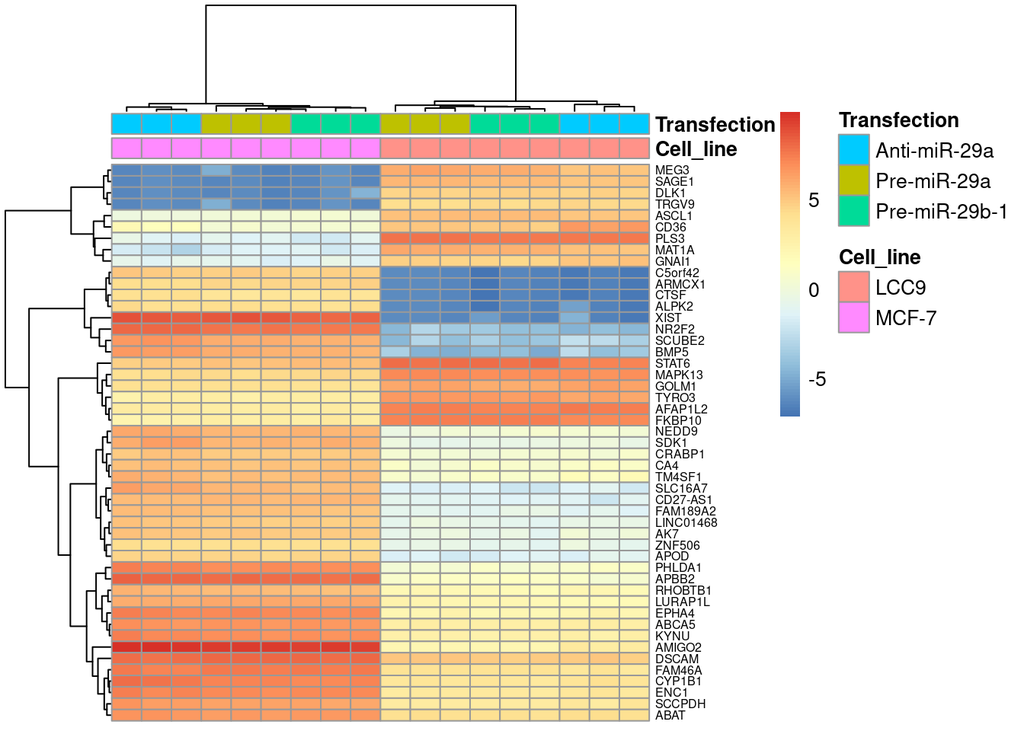

Heatmap

```r
## Guardemos los IDs de nuestros 50 genes
nombres_originales <- rownames(exprs_heatmap)

## Con match() podemos encontrar cual es cual
rownames(exprs_heatmap) <- rowRanges(rse_gene_SRP075398)$gene_name[
    match(rownames(exprs_heatmap), rowRanges(rse_gene_SRP075398)$gene_id)
]

## Guardar la imagen en un PDF largo para poder ver los nombres de los genes
pdf("pheatmap_con_nombres.pdf", height = 16, useDingbats = FALSE)
pheatmap(
    exprs_heatmap,
    cluster_rows = TRUE,
    cluster_cols = TRUE,
    show_rownames = TRUE,
    show_colnames = FALSE,
    annotation_col = df,
    fontsize_row = 6,
)
```

```r
dev.off()
```

```r
# MDS (multidimensional scaling)

## Convertir los grupos de Cell_line a colores
col.group <- df$Cell_line
levels(col.group) <- brewer.pal(nlevels(col.group), "Set2")
```

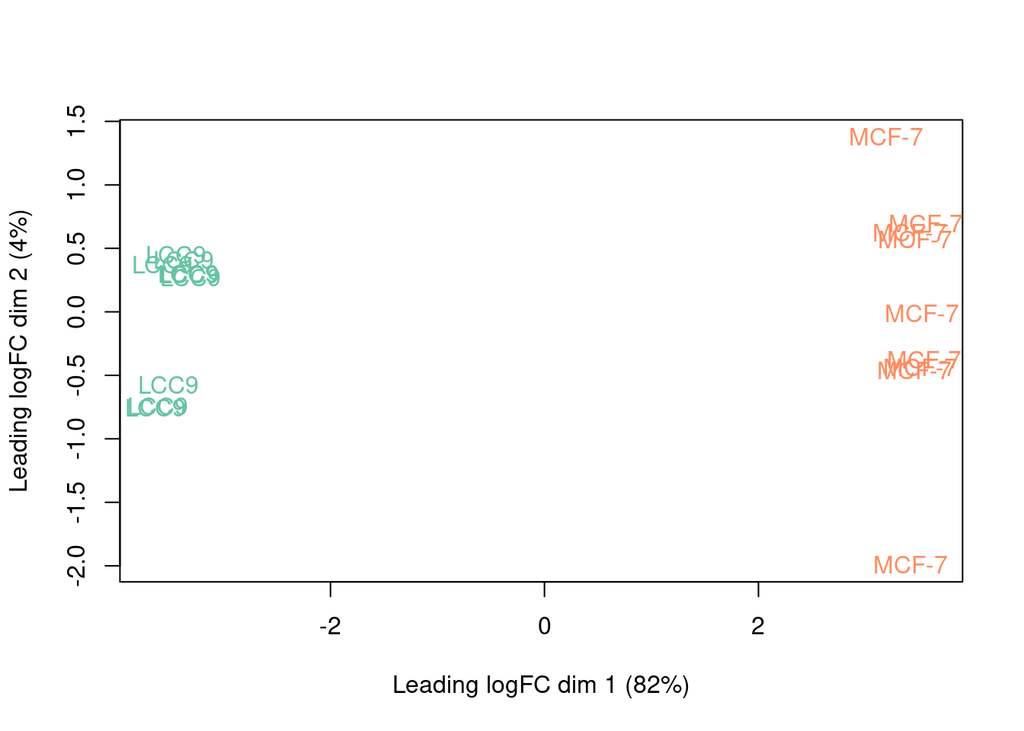

plotMDS Cell_Line

```r
col.group <- as.character(col.group)

## MDS por grupos de Cell_line
plotMDS(vGene$E, labels = df$Cell_line, col = col.group)
```

Este gráfico evalúa si las muestras se agrupan según la variable Cell_line, la separación clara entre MCF-7 y LCC9 indica que hay diferencias notables en la expresión génica entre estas líneas celulares. Esto sugiere que LCC9 y MCF-7 tienen perfiles de expresión distintos, lo que podría estar influenciado por la transfección con miR-29a/b. Por lo tanto, es posible que los genes regulados por miR-29a/b sean clave en la resistencia a la terapia endocrina.

[figure not shown]

plotMDS Transfection

```r
## Convertir Transfection a colores
col.group <- df$Transfection
df$Transfection <- as.factor(df$Transfection) # Asegúrate de que sea un factor
colors <- brewer.pal(nlevels(df$Transfection), "Set2") # Generar paleta de colores
levels(col.group) <- colors # Asignar colores a los niveles
col.group <- as.character(col.group) # Convertir a vector de caracteres

## MDS por grupos de Transfection
plotMDS(vGene$E, labels = df$Transfection, col = col.group,
        main = "MDS Plot by Transfection", pch = 16)

## Agregar leyenda
legend("center", legend = levels(df$Transfection), fill = unique(col.group),
       title = "Transfection Groups")
```

## Conclusión

El análisis de expresión diferencial realizado en este proyecto permitió identificar genes relacionados con la resistencia a la terapia endocrina en cáncer de mama. A través de diversas visualizaciones, se evidenciaron diferencias significativas en los perfiles de expresión entre las líneas celulares MCF-7 (sensibles) y LCC9 (resistentes). El heatmap mostró patrones distintivos de expresión génica entre ambas líneas celulares, destacando genes como AMIGO2 con mayor expresión en MCF-7, mientras que AFAP1L2, PLS3, STAT6 y FKBP10 presentaron niveles más altos en LCC9.

Además, los paquetes empleados en este estudio, son herramientas bioinformáticas muy útiles que permiten llevar a cabo un protocolo estándar para el análisis de expresión diferencial que incluye: procesamiento de datos, filtrado de genes, normalización, construcción de modelos y pruebas estadísticas. Por lo que, el conocimiento de este flujo de trabajo es fundamental para cualquier investigador que busca comprender mecanismos moleculares o desarrollar nuevas estrategias terapéuticas.

## Referencias

Law, Charity W., Yunshun Chen, Wei Shi, and Gordon K. Smyth. 2014. “Voom: Precision Weights Unlock Linear Model Analysis Tools for RNA-Seq Read Counts.” *Genome Biology* 15 (February). https://doi.org/10.1186/gb-2014-15-2-r29.

Muluhngwi, Penn, and Carolyn M. Klinge. 2021. “Identification and Roles of Mir-29b-1-3p and Mir29a-3p-Regulated and Non-Regulated Lncrnas in Endocrine-Sensitive and Resistant Breast Cancer Cells.” *Cancers* 13 (July). https://doi.org/10.3390/cancers13143530.